# Introduction to Agentic AI

Lecture 11a  
POLS 6394 · Tuesday, November 3

## November 3: where we left off

Lecture 10a showed how quickly agents changed, and why web chat doesn’t reveal everything they can do. This is the second part of the same lesson.

Today’s route:

1. Start the installation; it runs while we talk.
2. Learn the terms you’ll hear about AI tools; understand how models are trained, how they reason and what they cost.
3. Discuss the research debate and the Part II ground rules.
4. Check installation progress. A short practice lab is a backup if time remains.

We can stop at a module boundary. The backup lab, reproducibility and political bias follow the closing as reference.

# Install your tools

## Start the install now

The installs take 30 to 60 minutes, mostly downloading. Start them now; they run while we talk. First **pull** your course repository (Git tab, then **Pull**) to get the `Setup` folder. The full guide is `11a-setup-ai-tools.qmd`, next to this workbook; click **Render** to see it with your computer’s details.

Everything happens in RStudio’s **Terminal** tab: **Tools → Terminal → New Terminal**. It starts in your project.

| Mac | Windows |
| --- | --- |
| `cd Setup/mac` | `cd Setup/windows` |
| `/bin/bash install-macos-tools.sh` | `bash install-windows-tools.sh` |

A `.sh` file is a **shell script**, a saved list of terminal commands; `bash` (or `/bin/bash`) runs it.

The tools script installs a **package manager** first if you don’t have one: **Homebrew** on a Mac, **Scoop** on Windows. Homebrew asks for your Mac password, which doesn’t show as you type.

## What a package manager is

Apple and Microsoft both run app stores, but those are built for commercial apps with windows and icons. Most open-source software, and nearly every **command-line** tool, isn’t there. For those we use a **package manager**: Homebrew on a Mac, Scoop on Windows.

You already use one. CRAN is R’s package manager:

|  | R | Mac | Windows |
| --- | --- | --- | --- |
| Where packages come from | CRAN | Homebrew | Scoop |
| Install one | `install.packages("dplyr")` | `brew install jq` | `scoop install jq` |
| Update them all | `update.packages()` | `brew upgrade` | `scoop update *` |

Like CRAN, a package manager downloads the right version for your computer, installs what it depends on, and updates everything with one command. The scripts you just started are mostly a list of these installs.

## What you’re installing: tools agents use

- **Finding things:** `rg` searches inside files; `fd` finds files by name.
- **Reading data:** `jq` for JSON, `yq` for YAML, `sqlite3` for databases.
- **Files and documents:** `7z`, `zip`, and `unzip` for archives; `pandoc` converts formats; Poppler, qpdf, and Tesseract read and repair PDFs, including scanned ones; ImageMagick and Ghostscript convert images and PDFs.
- **Development:** `gh` for GitHub, `make`, Python with `uv`, Node.js.
- **Long jobs:** `pueue` queues commands to run in the background, so an agent can start one and check back.

An agent does its work through commands like these. When one is missing, it improvises, more slowly and less reliably.

## What you’re installing: tools for you

- **Getting around:** `zoxide` jumps to folders you use often; `mcfly` searches your past commands; `fzf` filters any list as you type; `micro` is a simple text editor; `tldr` shows short examples of a command.
- **Watching your computer:** `btop` shows what’s running; `fastfetch` summarizes your system.
- **Agents:** `herdr` runs several agents side by side in one terminal window.
- **Mac only:** OCRmyPDF, which makes scanned PDFs searchable, and **Ghostty**, the terminal app where you’ll run agents. Setup itself stays in RStudio.
- **Windows only:** the script makes `Rscript` work in any terminal and adds Git Bash to Windows Terminal, where you’ll run agents. New terminals open with a `fastfetch` summary.

## If a setup script fails

I wrote the two setup scripts, the tools script and the agents script, to automate the whole install. Here’s how to read what they print.

- Each tool prints one line. A failure shows `FAILED` or `MISSING`, then the last lines of its log.
- Running a script again is safe: it skips what’s already installed.
- Don’t retry with `sudo` or *Run as administrator*.
- **Windows:** if it says `uv was just installed`, reopen RStudio and run the tools script again. If `python` opens the Microsoft Store, see the setup guide.
- **Mac:** a laptop where you don’t have an administrator password can’t install Homebrew. Tell us.

Show Boris or Amanda the failed line, or post it in the discussion board’s Q&A.

## Store your OpenAI API key

The last setup step, also in the setup guide: store the key you’ll use to call models from R. R finds it in `.Renviron`, the same home-folder file that holds your Congress.gov key. Run this in the Console:

```r
usethis::edit_r_environ()
```

Keep the lines already there. On a new line, type `OPENAI_API_KEY`, an equals sign, and your key from platform.openai.com/api-keys, with no spaces or quotation marks. Save, then **Session → Restart R**, and check without printing the key:

```r
nzchar(Sys.getenv("OPENAI_API_KEY"))
```

`TRUE` means R found it. ellmer reads `OPENAI_API_KEY` on its own. Never put the key in a workbook or a chat.

# Terms you’ll hear

## Web chat

You type a request into a website and read the answer.

You can paste code, supply a document, or ask about a public dataset. If it proposes code, you can copy it into RStudio and run it yourself.

For a question about your data, supply the column names and types. Public-safe `glimpse()` output helps it write code for columns you actually have.

Some chat applications also browse or run tools. Check which features are active before sharing data.

## An assistant inside your editor

**Posit Assistant** works inside RStudio. It can read code and data in your project beyond the file you have open, and it can edit your code for you.

That puts it closer to an agent than to web chat: you don’t paste anything in. **Cursor**, a code editor built on Visual Studio Code, works the same way with its assistant built in.

Its edits land in your files. Commit before you ask, then inspect the diff afterward. It may send what it reads to the cloud, so keep keys and restricted data out of the project.

[RStudio: Posit Assistant](https://docs.posit.co/ide/user/ide/guide/tools/posit-ai.html)

## Calling a model from R

An **API** lets your program send requests and receive responses, as with the data APIs we’ve used.

For example, R can send each survey answer to a model and collect a category for each one. The ellmer package provides an R interface to model providers.

You write the workflow. A model call is one step inside it.

[ellmer documentation](https://ellmer.tidyverse.org/)

## System and user prompts

A **system prompt** gives standing instructions from the application or developer. A **user prompt** gives the request you’re making now.

**System example:** “When summarizing a study, distinguish its findings from your own interpretation.”

**User example:** “Summarize the attached paper’s evidence about turnout in one paragraph.”

The model receives both. A commercial application may include instructions you can’t inspect.

[OpenAI: prompt roles](https://developers.openai.com/api/docs/guides/prompt-engineering)

## Context, memory, and browsing

**Context** is the material available for the current response: instructions, conversation, supplied files, and tool results. It has a size limit, the **context window**.

An application’s **memory** may save information and supply it in later conversations. That differs from retraining the model.

In a typical web chat, context is mostly what you supply. An agent builds its own by reading files and running code, and summarizes older material when the window fills.

A codebook you paste into a request becomes context. Browsing can add a source fetched now. Neither action changes the underlying model.

Without your column names or a tool that reads the data, a model may guess `income` when your column is actually `household_income`. Supply that information rather than asking it to guess.

## The harness

An agent is a model running inside a **harness**: the program that sends requests to the model, runs the tools it asks for (read a file, run R code, search the web), and feeds the results back. Claude Code and Codex are harnesses.

The harness also manages context. When the window gets too full, it **auto-compacts**: it summarizes the conversation so far and continues from the summary.

Like Leonard in *Memento*, the agent then works from notes written by its earlier self. Details the summary left out are gone, and a mistake in the summary carries forward.

Put standing instructions in a file the harness rereads every session, such as `CLAUDE.md` or `AGENTS.md`, rather than only in the conversation.

## Skills

A **skill** bundles instructions for a recurring task, sometimes with scripts, examples, or templates.

A paper-checking skill might specify how to inspect citations and report missing references. The application loads those instructions when needed.

The underlying model stays the same. A skill is useful only if its instructions and supporting tools are sound.

[OpenAI: skills](https://developers.openai.com/api/docs/guides/tools-skills)

# How models work

## A model’s training corpus

A **corpus** is a collection of texts. For today’s large models, the training corpus is essentially the entire publicly accessible internet, plus books, code, and other material the developer collects or licenses.

During training, the model learns numerical **weights** from patterns in those examples. The weights determine how it produces responses.

Coverage is uneven. English is by far the largest share, so models know more, and write better, in English than in most other languages; the same holds for well-documented topics over obscure ones. A fluent answer doesn’t establish that the model saw reliable evidence about your question.

## Books in the corpus

Books are better-written and more carefully edited than most web pages, so labs want them.

Anthropic bought millions of print books, cut off the bindings, and scanned them. It also downloaded millions of pirated copies.

In *Bartz v. Anthropic*, the judge ruled in 2025 that training on the purchased books was fair use but keeping the pirated library was not. Anthropic settled with the authors for $1.5 billion, about $3,000 for each of roughly 480,000 books; the court approved it in July 2026.

The law is still being written: some authors have appealed, and suits against other labs are pending.

[Authors Alliance: final approval](https://www.authorsalliance.org/2026/07/21/bartz-v-anthropic-settlement-receives-final-approval/)

## Predicting the next token

A **token** is a piece of text, such as a word, part of a word, or punctuation.

During pretraining, a language model learns to predict the next token from the text before it. It generates a response by repeating that prediction.

After “The capital of France is”, “Paris” is a likely continuation. A plausible continuation to a question about an unfamiliar paper could instead be an invented citation.

Generating text doesn’t itself check a source or run the proposed code. Tools can do those jobs, but you still need to check their results.

## Hallucinations

A **hallucination** is generated content that is false or unsupported, such as an invented paper or a function argument that doesn’t exist.

It can appear in fluent prose or code that looks reasonable. Confidence and formatting don’t establish accuracy.

## Training and post-training

**Pretraining** teaches broad patterns by predicting parts of training examples.

**Post-training** adjusts behavior using examples and feedback: following instructions, answering helpfully, using tools, and refusing some requests.

Much of post-training is **reinforcement learning**: the model makes attempts, each attempt is scored, and the model shifts toward what scored well. The score can come from people’s ratings (as for ChatGPT in 2022), from answers that can be checked (math, code that must pass tests), or from finishing multi-step agent tasks.

Both the training material and these later choices can shape the answers you receive.

## Reasoning models

Since OpenAI’s o1 (September 2024), leading models can **reason** before answering: they generate intermediate tokens working through the problem, then write the response.

Reasoning was trained largely with reinforcement learning on checkable problems. The two aren’t the same thing: reinforcement learning is a training method with many uses, and reasoning is what the model does when it answers.

Reasoning helps most on hard, multi-step problems: debugging, planning an analysis, checking its own work. More effort isn’t always worth its cost and wait. Test it on your task.

It also makes agents more dependable on long tasks: planning steps, noticing an error, and trying again.

## Reasoning effort is a setting

Many applications and APIs let you choose how much the model reasons. OpenAI’s settings run from `low` to `high` and beyond; Anthropic calls it extended thinking.

- **Cost:** reasoning tokens are billed as output tokens, even when you don’t see them.
- **Time:** more reasoning means a slower answer.
- **Context:** reasoning tokens take up room in the context window.

What you see is often a **summary** of the reasoning. Treat it as a description, not proof of how the answer was reached. In research, record the reasoning setting along with the model.

[OpenAI: reasoning models](https://developers.openai.com/api/docs/guides/reasoning) · [Anthropic: extended thinking](https://platform.claude.com/docs/en/build-with-claude/extended-thinking)

# What it costs

## Why cost matters now

In your methods classes, computing is effectively free. Once you have a laptop, running a regression again, or a thousand times in a simulation, costs nothing but time.

Calling a model is different. Every request is **metered** and billed, like a taxi: rerunning a classification of 100,000 texts costs as much as the first run.

So cost becomes a research-design decision, alongside validity:

- Which model, and how much reasoning effort?
- How many texts, and how many repeated runs to check stability?
- Pilot on a small sample first, then scale up only once the prompt works.

A subscription hides the meter, but it still caps how much you can do.

## Tokens are the unit

- A **token** is a piece of text: a short word, part of a longer word, or punctuation. How a text splits depends on the model.
- **Input tokens**: everything you send, including instructions, the text to analyze, and earlier turns of the conversation.
- **Output tokens**: generated text, including billable reasoning where applicable. They usually cost several times as much as input: five times for the OpenAI and Anthropic models below.
- Prices are quoted per **million tokens**.

## What a million tokens costs

| Model | Input | Output |
| --- | --- | --- |
| Jev 1.13 (TypeSafe) | $0.04 | free |
| Claude Haiku 5.5, GPT-6 Luna | $0.10 | $0.50 |
| GPT-6.1 Terra | $1 | $5 |
| DeepSeek V4 Pro (open weights) | $1.32 | $3.96 |
| GLM-5.3 from Z.ai (open weights) | $1.40 | $4.40 |
| Claude Sonnet 5.5, GPT-6.1 Sol | $2 | $10 |
| Claude Opus 5.5 | $4 | $20 |

- Opus costs **40 times** as much as Haiku or Luna. The best open-weight models cost about what Terra does.
- **Jev** only classifies: it returns one of your categories, not prose, so output is free.

Standard API prices per million tokens, checked November 3, 2026: [Anthropic](https://platform.claude.com/docs/en/about-claude/pricing); [OpenAI](https://developers.openai.com/api/docs/pricing); [DeepSeek](https://api-docs.deepseek.com/quick_start/pricing) (peak rate; off-peak is half); [Z.ai](https://docs.z.ai/guides/overview/pricing); Jev via [OpenRouter](https://openrouter.ai/~typesafe). Prices change; check before you budget.

## More money buys less and less

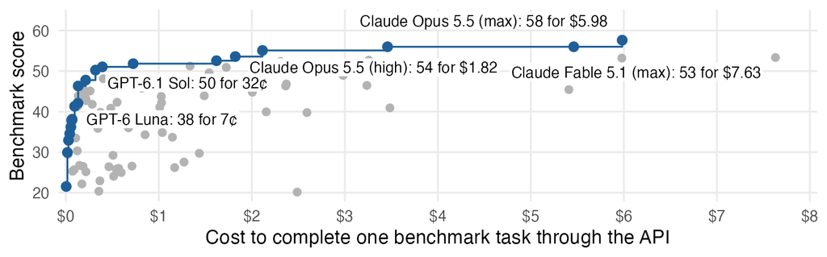

- Each dot is a model at one reasoning setting. The blue line, a **Pareto frontier**, joins the best buys: nothing scores higher for less.
- Scores climb fast up to about 50¢, then flatten: Opus 5.5 (max) costs **19 times** GPT-6.1 Sol (high) for 8 more points.
- Start with the cheapest model that is good enough, and check it on your own data.

[Artificial Analysis](https://artificialanalysis.ai/leaderboards/models) Intelligence Index v4.3.2, October 27, 2026.

## More effort, smaller gains

Combined benchmark score · API cost per benchmark task:

| Effort | GPT-6.1 Terra | GPT-6.1 Sol | Claude Opus 5.5 |
| --- | --- | --- | --- |
| low | 36 · $0.05 | 42 · $0.13 | 42 · $0.55 |
| **medium** | **41 · $0.10** | **48 · $0.21** | **51 · $1.34** |
| **high** | **44 · $0.13** | **50 · $0.32** | **54 · $1.82** |
| max | 48 · $0.40 | 52 · $0.72 | 58 · $5.98 |

[Artificial Analysis](https://artificialanalysis.ai/leaderboards/models) Intelligence Index v4.3.2, October 27, 2026.

## Classifying 1,000 survey answers

Each request sends about 500 tokens (instructions plus one answer) and gets back about 50 (a label and a short reason). 1,000 requests = 500,000 input + 50,000 output tokens:

| Model | Input | Output | Total |
| --- | --- | --- | --- |
| Jev 1.13 | 0.5 × $0.04 | free | **$0.02** |
| Haiku 5.5 or GPT-6 Luna | 0.5 × $0.10 | 0.05 × $0.50 | **$0.08** |
| GPT-6.1 Terra | 0.5 × $1 | 0.05 × $5 | **$0.75** |
| Sonnet 5.5 or GPT-6.1 Sol | 0.5 × $2 | 0.05 × $10 | **$1.50** |
| Opus 5.5 | 0.5 × $4 | 0.05 × $20 | **$3.00** |

Jev returns only the label and its confidence, no reason. A $5 credit goes a long way for one-label-per-text work.

## Why agents use so many tokens

- Agents make repeated requests, often including earlier conversation, files, and tool results.
- **Assume** a session totals 2 million input tokens and 100,000 output tokens across its requests. This is an illustration, not measured usage.
- At Sol’s uncached rates: 2 × $2 + 0.1 × $10 = **$5**. Twenty such sessions would cost **$100**.
- Reasoning adds output tokens at every step.
- **Caching** reuses previously processed input at a discount. Sol’s cached input costs $0.10 rather than $2 per million tokens.

## Subscription or API key?

There are two ways to pay for a model:

|  | API key | Subscription |
| --- | --- | --- |
| **You pay** | per token, metered | a flat monthly fee, $20 to $200 |
| **The limit** | your budget | usage caps that reset every few hours and every week |
| **Works in** | anything: your R code, any harness, other companies’ apps | generally only the company’s own apps: ChatGPT and Codex, or Claude and Claude Code |

The trade: a subscription gives up flexibility and gets far more use per dollar, as the next slide shows.

Why offer that deal? One argument is that subscriptions work partly as marketing. The big money is in API spending by companies. Most subscribers use far less than their limits, and heavy users get attached to the company’s own tools. That’s speculation; the companies don’t report it.

## Is a subscription “subsidized”?

For heavy agent use, a subscription buys far more than the same money spent on the API.

For agent work, a subscription is the cheap way to buy tokens. API credit is for code that calls a model, such as `ellmer`, where each call is billed and recorded.

[SemiAnalysis, October 5, 2026](https://newsletter.semianalysis.com/p/anthropic-subscriptions-offer-5x) · [Theo Browne’s estimates, summarized by BigGo, October 2, 2026](https://finance.biggo.com/news/fc836fe785cc12ba)

## Spending a small budget well

Cost is a constraint to design around, not a reason to skip these tools.

- **Match the model to the task.** Labeling texts rarely needs a frontier model; save Terra or Sol for the hard cases.
- **Pilot first.** Label 50 texts yourself, then run a cheap model and an expensive one on them. Scale up with the cheapest model that agrees with you well enough.
- **Send fewer tokens.** Keep instructions short, ask for a label rather than an explanation, and reuse the same instructions so caching discounts them.
- **Let it wait.** Batch jobs that can finish overnight cost half.
- **Delegate.** In an agent, use a strong model such as Sol as the project manager. Ask it to hand routine subtasks to **subagents** running Terra or Luna, then check their work. You pay Sol’s rates mainly for planning and review.

## Even a tiny budget works

Classifying **100,000** survey answers at 500 tokens each:

- **Jev:** about **$2**. **GPT-6 Luna:** about **$8**.
- **Muse Spark Contributor** ($0.10 in, $0.20 out): about $6, but Meta may train on what you send, so use it only for public data.
- **Open-weight models** cost little through an API, or nothing per call on your own computer, which also keeps restricted data at home.

When your research needs more, budget it like any other research expense. Put API costs in dissertation and grant proposals as a line item, estimated from your pilot, and look for the research-credit programs that AI companies run.

# Part II Ground Rules

## Part II has already begun

The AI policy changed after the midterm on **October 27**, not today.

AI is required on Part II assignments. **Problem Set 5 remains AI-off**, even though it was due this morning.

Part I gave you practice reading code and checking results. You’ll use those skills when an assistant writes the code.

## What you’re responsible for

You need to understand the code you submit and check that it answers the question.

The two AI critique assignments ask you to document what the tool got wrong, how you caught it, and what you checked yourself. Follow each assignment’s instructions.

Today’s workbook is a place for your notes, not another critique assignment.

# The Debate Over AI in Research

## Hall: what could researchers do with more capacity?

Hall describes using an agent to extend a vote-by-mail study, then commissioning an independent manual audit.

His proposal is broader than writing papers faster: research that keeps updating as new data arrive, and teams that can examine more questions.

What still needs people? Choosing the question, judging the design, and checking whether the result is right.

[Andrew Hall, The 100x Research Institution](https://freesystems.substack.com/p/the-100x-research-institution), January 13, 2026.

## Kustov’s argument changes across the three posts

- **Part I:** current AI capabilities should change how academics work and publish.
- **Part II:** responses raise concerns about qualitative work and losing skills.
- **Part III:** what should academics do differently if producing a paper becomes much easier?

Choose a claim from the posts, not just whether you like their overall position.

Alexander Kustov, [Part I](https://www.popularbydesign.org/p/academics-need-to-wake-up-on-ai), [Part II](https://www.popularbydesign.org/p/academics-need-to-wake-up-on-ai-part), [Part III](https://www.popularbydesign.org/p/academics-need-to-wake-up-on-ai-part-4c6).

## Faster production and better research

Suppose an assistant lets you run a hundred more specifications.

That could expose a fragile finding. It could also give you a hundred chances to select the result you wanted.

## A risk: feeling that you understand more than you do

Messeri and Crockett warn that researchers can mistake fluent assistance for understanding.

If many researchers use similar tools and accept similar suggestions, the range of questions and methods may narrow.

For your project: could you explain why an analysis is appropriate, rather than only show that its code ran?

Lisa Messeri & M. J. Crockett, [Artificial intelligence and illusions of understanding in scientific research](https://doi.org/10.1038/s41586-024-07146-0), Nature (2024). Background for discussion; not an additional reading assignment today.

## Another risk: slop

**Slop** is content that is cheap to produce and poorly written or poorly conceived. AI makes a plausible-looking paper cheap; it doesn’t make a good question or a sound design cheap.

Peer review runs on volunteer time. A flood of weak submissions takes reviewers away from the good ones, and some bad work gets through.

It’s already happening. In October 2025, arXiv stopped accepting computer-science review and position papers that hadn’t passed peer review, after a flood of LLM-written surveys its volunteer moderators couldn’t keep up with.

For your project: what would a reviewer find in it that a quick AI draft wouldn’t have?

[arXiv blog: CS review and position papers](https://blog.arxiv.org/2025/10/31/attention-authors-updated-practice-for-review-articles-and-position-papers-in-arxiv-cs-category/) · [404 Media](https://www.404media.co/arxiv-changes-rules-after-getting-spammed-with-ai-generated-research-papers/)

## A different question: how adoption happens

Narayanan and Kapoor distinguish improvements in models from their adoption in real organizations.

Better software doesn’t automatically supply usable data, change incentives, or decide who is responsible for a mistake.

How much of Hall’s proposal needs better models, and how much needs a different research institution?

Arvind Narayanan & Sayash Kapoor, [AI as Normal Technology](https://knightcolumbia.org/content/ai-as-normal-technology), April 15, 2025. Background for discussion; not an additional reading assignment today.

## Research and training are different questions

Part I’s AI ban was a teaching decision: you needed to do the work yourself before supervising a tool.

Whether AI belongs in research production is a separate argument. Speed, validity, privacy, and disclosure all matter.

In this course, AI assistance is allowed in Part II research work. You remain responsible for the result.

## Writing needs its own checks

Running code can reveal an error, but successful execution doesn’t establish a sound analysis.

The paper’s claims and reasoning must be yours. Record AI use as the assignment and project instructions require.

## Your Turn: a claim and a test

*~3 minutes, discussion.*

Use the note you brought from Hall or Kustov.

State one claim you find convincing or want to challenge. Then propose evidence that could change your view.

Record the claim and the proposed test in the workbook.

# Checking an AI Answer

## Useful work with an answer you can check

An assistant can explain an unfamiliar pipeline, propose a fix, or draft a plotting change.

Before asking, decide what would count as success: the expected rows, a known total, a figure with specified labels, or a comparison with a trusted source.

You’ll need that check whether the assistant succeeds or fails.

## Where checking is harder

Some errors are easy to miss: an inappropriate denominator, a join that duplicates observations, or a claim that goes beyond the design.

A correct-looking number may come from the wrong calculation.

When you can’t yet check the answer, ask for a smaller step or get help with the underlying method.

## A reproducible error can still be an error

**Reproducible** means someone else can rerun your code on your data and get the same numbers. King’s replication standard asks for exactly that. It’s necessary, but it isn’t enough.

Suppose an assistant writes a script that divides votes by total population instead of eligible voters. It renders cleanly and gives the same answer every time: the same wrong answer.

Rerunning shows that the code does what it says. It doesn’t show that what it says is right. That takes an independent check: a known total, a hand count, or a second method.

Hall’s audit is the model. A PhD student redid the AI’s replication by hand and still found missed races and skipped calculations. The backup lab practices the same check on a smaller scale.

Gary King, [Replication, Replication](https://gking.harvard.edu/publication/replication-replication/), PS: Political Science & Politics (1995) · Andy Hall, [The 100x Research Institution](https://freesystems.substack.com/p/the-100x-research-institution) (2026).

# Can you rerun it?

## Cloud models can disappear

A paper can name a hosted model exactly and still become impossible to rerun when the provider retires it.

For example, OpenAI lists **July 14, 2025** as the shutdown date for `gpt-4.5-preview`.

A dated model version helps identify what you used while it remains available. It doesn’t guarantee permanent access.

[OpenAI: API model shutdowns](https://developers.openai.com/api/docs/deprecations)

## Local models can be archived

If the license permits, you can keep the exact weights and the files needed to run them, even after the developer stops offering downloads.

Keep the **tokenizer**, which divides text into tokens, and the software and settings used to run the model too.

That gives you much more control over future reruns. Compatible hardware and preserved software still matter, so “forever” requires maintenance and backups.

## A rerun may still differ

Keeping the model doesn’t guarantee word-for-word identical answers.

Random sampling, software versions, hardware, and numerical differences can affect generation. A random seed alone may not eliminate those differences.

**Temperature**, where supported, adjusts sampling: lower settings favor likely tokens; higher settings allow more variation. Low temperature doesn’t guarantee truth or identical reruns.

For research, separate **rerunning the model** from **reproducing the analysis of saved model outputs**. The second should remain possible even when the first isn’t.

[PyTorch: limits of reproducibility across environments](https://docs.pytorch.org/docs/2.14/notes/randomness.html)

## What belongs in the replication files?

- Exact model/version, provider, and date of use
- System and user prompts, supplied data, and generation settings (temperature, reasoning effort)
- Raw responses, including errors and retries
- Code that turns those responses into the paper’s results
- For local models: weight files or a permitted archive, software versions, and a checksum to identify the exact files

Protect restricted data and credentials. Save public-safe records without putting API keys in the repository.

## Before Next Class

**November 5 project checkpoint:** one real result or an approved equivalent.

# Reference Modules

# Backup lab: supervised practice

*Optional backup lab, only if class time remains. It isn’t required, and you don’t need to do it later.*

## Posit Assistant

This lab uses **Posit Assistant**, the editor assistant from earlier. It’s built into RStudio 2026.04 and later.

- **Open it:** click **Posit Assistant** on the toolbar. The first time, click **Install Posit Assistant**.
- **Connect it:** click **Configure provider**, choose **OpenAI**, and supply the API key you stored earlier. It bills your credit by the token, as ellmer does.
- **What it sees:** your project’s code and data, and your R session, including `cspp` once you’ve loaded it. You don’t paste anything in.
- **What it can do:** write code, and edit your files directly.

Commit before you ask. Afterward, inspect the diff in the Git pane, and read any code before you let it run. Keep keys and restricted data out of the project.

[RStudio: Posit Assistant](https://docs.posit.co/ide/user/ide/guide/tools/posit-ai.html)

## Warm-up: a toy request

*~5 minutes.*

Practice asking on a problem small enough to check in your head: three made-up states, with votes and eligible voters.

1. Run the chunk that creates `toy`.
2. Paste the workbook’s prompt into Posit Assistant. It asks for a `turnout` column.
3. **Run** the code it writes and **check** the three turnout values by hand.

The tasks below add two steps to this loop: commit before you ask, and inspect the diff before you run.

## Setup

Run this chunk as written. The supplied CSPP teaching extract has one row per state and year.

```r
library(tidyverse)
cspp <- read_csv("Data/state_policy/cspp_states.csv", show_col_types = FALSE)
```

`cspp` is the public teaching data frame we used in Part I. Keep it unchanged.

## Five sampled rows

```r
set.seed(6394)
cspp |>
  select(st, year, pid, ideo, pollib_median) |>
  slice_sample(n = 5)
```

```
# A tibble: 5 × 5
  st     year   pid  ideo pollib_median
  <chr> <dbl> <dbl> <dbl>         <dbl>
1 IN     2019 NA    NA             NA
2 AZ     1987 -0.05 -0.09          -0.7
3 FL     1997  0.03 -0.12          -0.6
4 CT     2002  0.14  0.13           1.7
5 WY     1986 -0.03  0.17          -0.5
```

This shows five columns. The full data frame has 25 columns and 2,205 rows.

## Practice: compare against known results

*~15 minutes total after the warm-up, including ordinary troubleshooting.*

Now the same loop on real data.

1. Run the supplied missing-value counts. Make one small change to the displayed rows.
2. Ask Posit Assistant for the same counts, in a specified format.
3. Compare the results and record what you checked.

The point is to decide whether to keep this particular answer. You don’t need two accounts, and you don’t have to find an error.

## Task 1: the baseline

*~4 minutes; worked.*

The workbook counts missing values in every column.

`is.na()` marks missing cells as `TRUE`. `colSums()` adds within each column, counting `TRUE` as 1 and `FALSE` as 0.

The displayed checks are `pid`: **441**, `ideo`: **441**, and `year`: **0**. Keep the full baseline for comparison.

## Task 2: ask once

*~6 minutes.*

Now add the two steps. Commit the workbook first, then paste the workbook’s prompt into Posit Assistant. It asks for a tibble called `ai_counts`, with the columns `column` and `n_missing`, written into the workbook’s disabled chunk.

Record the model label the pane shows; “not shown” is fine. Then inspect the diff in the Git pane before you run anything.

Keep `cspp` and `baseline` unchanged. If the answer errors, record the first error rather than starting a long repair.

## Task 3: check and explain

*~5 minutes.*

Check the column names and output format, then use the workbook’s supplied comparison to check the counts. Other output describes a difference or error to investigate.

Record one numerical check and whether the requested output format was met. If the answer is correct, say so.

A different function or output order isn’t automatically a mistake.

# Do models have politics?

## Do LLMs lean left? A study

[Westwood, Grimmer, and Hall](https://modelslant.com/paper.pdf) asked people to judge political slant: 10,007 U.S. respondents compared answers from 24 models on 30 topics.

- Nearly all models were **perceived** as left-leaning, including by many Democrats.
- Asking for an ideologically neutral position made responses look more neutral.

Westwood, Grimmer & Hall, *Measuring Perceived Slant in Large Language Models Through User Evaluations*, working paper, May 8, 2025.

## What the slant study measures

- It measures **perceived slant**, not whether an answer is true. The authors chose value-laden topics and discuss that limitation.
- These were **spring 2025 model versions**, several generations old now. The study doesn’t establish how today’s versions behave.
- The respondents and topics were American. Results may differ elsewhere.

Prompt wording changed the ratings, which is another reason to report the prompts in your research.

## Political censorship: a comparison

[Pan and Xu](https://xu-xu.net/xuxu/llmcensorship.pdf) compared four models from China with five from outside it. They asked 145 political questions in Chinese, 100 times each.

| Models tested | Approximate refusal rates |
| --- | --- |
| From China | 10% to 60% |
| From outside China | 0% to 3% |

The models from China also gave shorter and more often wholly inaccurate answers. Differences were smaller on less-sensitive questions.

Pan & Xu, [Political Censorship in Large Language Models Originating from China](https://doi.org/10.1093/pnasnexus/pgag013), *PNAS Nexus*. Specific models and versions, not all Chinese models.

# If Time Remains

## Extension 1: what would catch a wrong count?

*~8 minutes, discussion.*

An assistant produces the right number of rows and plausible counts. Is that enough?

Invent a small change to its result that would pass a row-count check but fail a value check. Explain what you’d compare to catch it.

Record your example and the check in the workbook. You don’t need another model call.

## Extension 2: what context would help?

*~8 minutes, discussion.*

Choose a question about data from your own research. Describe the context a model would need: column definitions, the unit of observation, or an example of the desired result.

Write a request using a synthetic example or column descriptions only. Don’t send confidential data.

Which parts could you check independently? If none, make the request smaller.

## Extension 3: a reproducibility decision

*~5 minutes, discussion only*

Your paper used a cloud model that the provider has retired. You saved the prompts, raw responses, and analysis code.

Which parts of the study can another researcher still reproduce? What would running a newer model add, and why wouldn’t it be an exact rerun?

## Extension 4: a skill for your research

*~5 minutes, discussion only*

Suppose you want a reusable skill for checking a Quarto paper before submission.

Name one instruction, one file or template it should consult, and one check that should run outside the model. What permission would that check need?

## Reference: long prompts and batch pricing

| Model | Long-prompt threshold | Standard-rate change |
| --- | --- | --- |
| Haiku 5.5 | More than 100,000 input tokens | Input and output ×5 |
| GPT-6 Luna and GPT-6.1 Sol | More than 272,000 input tokens | Input ×2; output ×1.5 |

Batch processing, which can wait rather than reply immediately, costs half the standard input/output rates on the five models compared here.

The syllabus still names **GPT-5.6 Luna** ($0.20 input / $1.20 output per million). This comparison doesn’t assign students a new model.

Standard rates checked October 25, 2026: [Anthropic](https://platform.claude.com/docs/en/about-claude/pricing); [OpenAI](https://developers.openai.com/api/docs/pricing).